# Summary Statistics

Edward A. Roualdes

# Basic R

## Data Frames in R

Run these commands in R

```r
suppressMessages(library(openintro))
data(email) # load dataset email
str(email)  # ensure we're looking at a df
head(email) # top 6 rows; try tail
head(email, n = 10) # use n = x, for head/tail
email$spam  # just one variable
names(email) # column names
some_cols <- c("spam", "num_char", "format", "number")
email[ , some_cols] # specified variables/columns
email[c(1,2,3,50), some_cols] # Table 1
```

# Categorical Data

## recap: `email`

Recall the `email` data set.

```r
data(email)
head(email[, c("spam", "format", "number")])
```

```
# A tibble: 6 × 3
  spam  format number
  <fct> <fct>  <fct>
1 0     1      big
2 0     1      small
3 0     1      small
4 0     1      small
5 0     0      none
6 0     0      none
```

## `email`, table

A good start

```r
table(email$number)
```

```
 none small   big
  549  2827   545
```

## `email`, contingency table

A **contingency table** is a table that summarizes data for two categorical variables.

```r
(t <- table(email$spam, email$number))
```

```
    none small  big
  0  400  2659  495
  1  149   168   50
```

## `email`, contingency table of proportions

```r
round(prop.table(t), 2)
```

```
    none small  big
  0 0.10  0.68 0.13
  1 0.04  0.04 0.01
```

# Numerical Data

## `county` data

Consider U.S. county data. Which of these variables is/are numerical?

```r
data(county)
tail(county[, c("name", "state", "pop2010", "per_capita_income")], n=4)
```

```
# A tibble: 4 × 4
  name            state   pop2010 per_capita_income
  <chr>           <fct>     <dbl>             <dbl>
1 Teton County    Wyoming   21294            48557.
2 Uinta County    Wyoming   21118            27048.
3 Washakie County Wyoming    8533            27495.
4 Weston County   Wyoming    7208            33297.
```

# Measures of Center

## Summary Statistics, mean

The **sample mean**, denoted $\bar{x}$, is the sum of a sample of numbers divided by how many numbers are in the sample. Mathematically, we write

$$\begin{align*}
\bar{x} & = \frac{x_1 + x_2 + \ldots + x_n}{n} \\
& = \frac{\sum_{i=1}^n x_i}{n} \\
& = \frac{1}{n} \sum_{i=1}^n x_i
\end{align*}$$

## Summary Statistics, mean: example by hand

Find the mean of the following numbers

```r
x <- sample(0:100, 10)
x
```

```
 [1] 72 12 39 77 78 76 98 79 87 97
```

## Summary Statistics, mean: example by R (computer)

```r
x
```

```
 [1] 72 12 39 77 78 76 98 79 87 97
```

```r
(m <- mean(x))
```

```
[1] 71.5
```

## Mean, by picture

Where is the mean relative to the data?

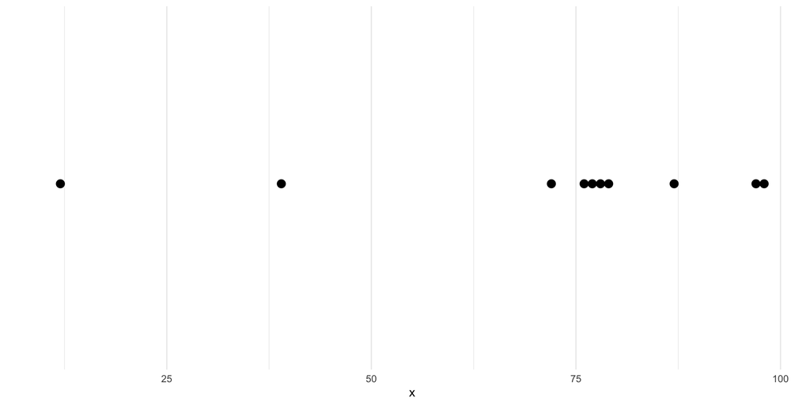

## Mean, by picture

Where is the mean relative to the data?

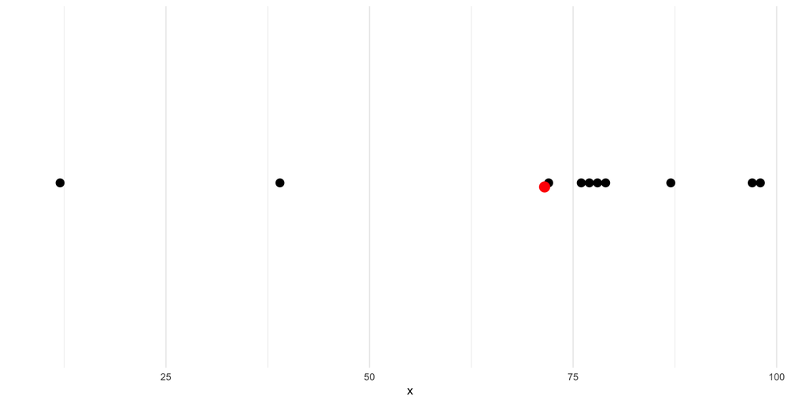

## Mean, an example

Find the mean of a variable stored in a data frame.

```r
mean(county$pop2010)
```

```
[1] 98262.04
```

## Mean, another example

Find the mean of a variable stored in a data frame.

```r
mean(email$num_char)
```

```
[1] 10.70659
```

## Mean, point estimator

We call the sample mean a **point estimator**. What is it estimating?

## Summary Statistics, median

**median**. If the data are ordered from smallest to largest, the **median** is the observation right in the middle. If there are an even number of observations, there will be two values in the middle, and the median is taken as their mean. There is no *simple* mathematical expression for this statistic.

## Summary Statistics, median: examples by R

Find the median of the following numbers:

```r
x
```

```
 [1] 72 12 39 77 78 76 98 79 87 97
```

```r
median(x)
```

```
[1] 77.5
```

## Summary Statistics: comparing measures of center

Both the mean and the median measure the center of a dataset. Thus, they are jointly referred to as measures of center.

```r
mean(x)
```

```
[1] 71.5
```

```r
median(x)
```

```
[1] 77.5
```

Though they measure different centers.

## What does more data do?

If we add a number to the previous variable `x`, what will be the effect on the

- mean?
- median?

## What does more data do?

… join $100$ to `x`

```r
mean(x)
```

```
[1] 71.5
```

```r
mean(c(x, 100))
```

```
[1] 74.09091
```

```r
median(x)
```

```
[1] 77.5
```

```r
median(c(x, 100))
```

```
[1] 78
```

## What does more data do?

How about joining $10000$ to `x`.

```r
mean(x)
```

```
[1] 71.5
```

```r
mean(c(x, 10000))
```

```
[1] 974.0909
```

```r
median(x)
```

```
[1] 77.5
```

```r
median(c(x, 10000))
```

```
[1] 78
```

## Summary Statistics, outliers

An **outlier** is an observation that appears extreme relative to the rest of the data.

Note

- The number $10000$ in the datasets above appears to be an outlier.
- What effect did this value have on the mean? On the median?
- What would have happened if we added $-100$? mean? median?
- Outliers are often the outcome of a confounding variable.

# Measures of Spread/Width

## Summarizing Data, data width

Means and medians help summarize the center of the data. The statisticians rigorous description of the width of data uses the idea of **deviations**. See OS4 section $2.1.4$.

## Deviations, defined

**deviation**. We call the distance between an observation and the mean its deviation. Mathematically, we write

$$d_i = x_i - \bar{x}$$

## Variance and Standard Deviation

The two most common measures of spread are the sample **variance** and the sample **standard deviation**.

The **sample variance** is (almost) the average of the squared deviations.

$$s^2 = \frac{d_1^2 + d_2^2 + \ldots + d_n^2}{n-1} = \frac{1}{n-1}\sum_{i=1}^n d_i^2$$

The **sample standard deviation** is the square root of the variance.

$$s = \sqrt{s^2}$$

## Standard Deviation in R, a simple example

```r
sd(email$num_char)
```

```
[1] 14.64579
```

## Notation of Populations

Recall, sample datasets provide information about the population.

- The sample mean $\bar{x}$ estimates the population mean $\mu$.
- The sample standard deviation $s$ estimates the population standard deviation $\sigma$.

## Standard Deviation Describes Variability

Focus on the conceptual meaning of the standard deviation as a descriptor of variability rather than the formulas.

# Other Measures of Spread

## Towards Other Measures of Spread

The median is also called the 50th quantile, or $Q_2$. There are other quantiles.

The **$q$th quantile** is the value that puts $q$% of the observations below this number. Also **percentile**.

- The 25th quantile is also known as the first quartile, or $Q_1$.
- The 75th quantile is also known as the third quartile, or $Q_3$.

## Towards Other Measures of Spread, continued

Another way to think about the 25/75th quantile.

- The 25th quantile is the median of the dataset that consists of the smallest number up to the median.
- The 75th quantile is the median of the dataset that consists of the median up to the largest number.

## Interquartile Range

The **IQR** is calculated the the difference between the 75th and the 25th quantile, $Q_3$ and $Q_1$, respectively:

$$IQR = Q_3 - Q_1$$

## Quantiles and IQR in R

```r
quantile(email$num_char, 0.25)
```

```
  25%
1.459
```

```r
q <- quantile(email$num_char, c(0.75, 0.25))
q[1] - q[2]
```

```
   75%
12.625
```

```r
IQR(email$num_char)
```

```
[1] 12.625
```

# Mixing Types

## Mixing Variable Types

Often with binary categorical data, it’s advantageous to encode the variable numerically. For example,

- female $\Rightarrow 1=$ female, $0=$ other
- high school educated $\Rightarrow 1=$ yes, $0=$ other (no)
- took pill $\Rightarrow 1=$ yes, $0=$ no
- …

## Mixing Variable Types

Consider the variable `spam` in the dataset `email`. We are likely interested in the proportion of emails that are spam, $\hat{p}$.

```r
spam_number <- ifelse(email$spam == 1, 1, 0)
(phat <- mean(spam_number))
```

```
[1] 0.09359857
```

## Take Away

- Summarizing data is crucial to statistics
- Mean and standard deviation are by far most important
  - study their interpretations and intuitions
  - see OS4 section 2.1.2 and 2.1.4
- we would prefer everything to be a mean, of sorts.